# An Examination of the Effects of Diet, Exercise, and Sleep on Weight

# 1 Setup and Data Ingest

The following section covers the loading of the `libraries`, scripts and data necessary to complete this study.

## 1.1 Initial Setup and Package Loads

This section loads the packages and global setup options necessary for this analysis with the code below:

```r
library(knitr)
library(rmdformats)
library(janitor)
library(magrittr)
library(naniar)
library(broom)
library(patchwork)
library(nhanesA)
library(measurements)
library(readxl)
library(Epi)
library(Hmisc)
library(tidyverse)
source("data/Love-boost.R")

opts_chunk$set(comment=NA)
opts_knit$set(width=75)

theme_set(theme_bw())
```

## 1.2 Loading the Raw Data into R

The `nhanesA` package was used to load all of the necessary NHANES data directly into R as tibbles, which were then saved to the `data` sub directory using the `saveRDS` function. While it’s technically unnecessary to save local copies of these files outside of R, it is good practice to do so, as it keeps R from needing to download the files every time these raw files are queried. These local copies were then read back into R as raw files for further data processing:

```r
DEMO_J_raw <- nhanes('DEMO_J') %>% tibble()
```

```
Processing SAS dataset DEMO_J    ..
```

```r
BMX_J_raw <- nhanes('BMX_J') %>% tibble()
```

```
Processing SAS dataset BMX_J     ..
```

```r
WHQ_J_raw <- nhanes('WHQ_J') %>% tibble()
```

```
Processing SAS dataset WHQ_J     ..
```

```r
PAQ_J_raw <- nhanes('PAQ_J') %>% tibble()
```

```
Processing SAS dataset PAQ_J     ..
```

```r
RXQ_RX_J_raw <- nhanes('RXQ_RX_J') %>% tibble()
```

```
Processing SAS dataset RXQ_RX_J      ..
```

```r
SLQ_J_raw <- nhanes('SLQ_J') %>% tibble()
```

```
Processing SAS dataset SLQ_J     ..
```

```r
saveRDS(DEMO_J_raw, "data/DEMO_J.Rds")
saveRDS(BMX_J_raw, "data/BMX_J.Rds")
saveRDS(WHQ_J_raw, "data/WHQ_J.Rds")
saveRDS(PAQ_J_raw, "data/PAQ_J.Rds")
saveRDS(RXQ_RX_J_raw, "data/RXQ_RX_J.Rds")
saveRDS(SLQ_J_raw, "data/SLQ_J.Rds")

DEMO_J_raw <- readRDS("data/DEMO_J.Rds")
BMX_J_raw <- readRDS("data/BMX_J.Rds")
WHQ_J_raw <- readRDS("data/WHQ_J.Rds")
PAQ_J_raw <- readRDS("data/PAQ_J.Rds")
RXQ_RX_J_raw <- readRDS("data/RXQ_RX_J.Rds")
SLQ_J_raw <- readRDS("data/SLQ_J.Rds")
```

# 2 Cleaning the Data

## 2.1 Selecting & Filtering for Relevant Data

Before merging the necessary tibbles to create the analysis data sets, the raw data files should be filtered and cleaned to ensure only the relevant data from each raw file is retained and is properly formatted. The filtered versions of the raw tibbles were created below to filter out incomplete data and select the appropriate variables that will be used in each analysis, using the keys for each data set as provided on the NHANES website to filter out missing and / or unwanted data. While each variable will be clarified in detail later in the Codebook section, the following is worth noting about the keys from the NHANES website:

- 7, 7777, and 77777 all represent instances where the respondent refused to respond to the question
- 9, 9999, and 99999 all represent instances where the respondent reported that they didn’t know the answer to the question
- “.” designate entries with missing entries

Additionally, a new variable was created that combines the results from `WHQ060` and `WHQ070` in the code below, however the reason for this will be explained in detail later in the cleaning section. The filtering code is as follows:

```r
DEMO_J_data = DEMO_J_raw %>%
  select(c(SEQN, RIDSTATR, RIDAGEYR)) %>%
  filter(RIDSTATR == 2) %>%
  filter(RIDAGEYR != ".") %>%
  filter(RIDAGEYR <= 79) %>%
  filter(RIDAGEYR >= 19)

BMX_J_data = BMX_J_raw %>%
  select(c(SEQN, BMXWT)) %>%
  filter(BMXWT != ".")

PAQ_J_data = PAQ_J_raw %>%
  select(c(SEQN, PAQ650)) %>%
  filter(PAQ650!= ".") %>%
  filter(PAQ650 != 7) %>%
  filter(PAQ650 != 9)

SLQ_J_data = SLQ_J_raw %>%
  select(c(SEQN, SLQ120)) %>%
  filter(SLQ120 != ".") %>%
  filter(SLQ120 != 7) %>%
  filter(SLQ120 != 9)

RXQ_RX_J_data1 = RXQ_RX_J_raw %>%
  select(c(SEQN, RXDUSE, RXDDAYS)) %>%
  filter(RXDUSE != ".") %>%
  filter(RXDUSE != 7) %>%
  filter(RXDUSE != 9) %>%
  filter(RXDDAYS != ".") %>%
  filter(RXDDAYS != 77777) %>%
  filter(RXDDAYS != 99999) %>%
  filter(RXDDAYS == 365) %>%
  select(c(SEQN, RXDUSE)) %>%
  distinct(data = , SEQN, .keep_all = TRUE)

RXQ_RX_J_data2 = RXQ_RX_J_raw %>%
  select(c(SEQN, RXDUSE, RXDDAYS)) %>%
  filter(RXDUSE == 2) %>%
  select(c(SEQN, RXDUSE)) %>%
  distinct(data = , SEQN, .keep_all = TRUE)

RXQ_RX_J_data = full_join(RXQ_RX_J_data1, RXQ_RX_J_data2)
WHQ_J_data1 = WHQ_J_raw %>%
  select(c(SEQN, WHQ060)) %>%
  filter(WHQ060 != ".") %>%
  filter(WHQ060 != 7) %>%
  filter(WHQ060 != 9) %>%
  mutate(WHQ065 = fct_recode(as.factor(WHQ060),
                             "Yes" = "1",
                             "No" = "2")) %>%
  select(c(SEQN, WHQ065))

WHQ_J_data_1a = WHQ_J_data1 %>%
  filter(WHQ065 == "Yes")

WHQ_J_data_1b = WHQ_J_data1 %>%
  filter(WHQ065 == "No")

WHQ_J_data2 = WHQ_J_raw %>%
  select(c(SEQN, WHQ070)) %>%
  filter(WHQ070 != ".") %>%
  filter(WHQ070 != 7) %>%
  filter(WHQ070 != 9) %>%
  mutate(WHQ065 = fct_recode(as.factor(WHQ070),
                              "Yes" = "1",
                              "No" = "2")) %>%
  select(c(SEQN, WHQ065))

WHQ_J_data_2a = WHQ_J_data2 %>%
  filter(WHQ065 == "Yes")

WHQ_J_data_2b = WHQ_J_data2 %>%
  filter(WHQ065 == "No")


WHQ_J_data_3a = full_join(WHQ_J_data_1a, WHQ_J_data_2a, by = c("SEQN", "WHQ065"))

WHQ_J_data_3b = full_join(WHQ_J_data_1b, WHQ_J_data_2b, by = c("SEQN", "WHQ065"))

WHQ_J_data_3c = anti_join(WHQ_J_data_3b, WHQ_J_data_3a, by = "SEQN")

WHQ_J_data3 = full_join(WHQ_J_data_3a, WHQ_J_data_3c, by = c("SEQN", "WHQ065"))


WHQ_J_data4 = WHQ_J_raw %>%
  select(c(SEQN, WHD020, WHD050)) %>%
  filter(WHD020 != ".") %>%
  filter(WHD020 != 7777) %>%
  filter(WHD020 != 9999) %>%
  filter(WHD050 != ".") %>%
  filter(WHD050 != 7777) %>%
  filter(WHD050 != 9999)


WHQ_J_data5 = WHQ_J_raw %>%
  select(c(SEQN, WHD080Q)) %>%
  filter(WHD080Q != ".")

WHQ_J_data = left_join(inner_join(WHQ_J_data3, WHQ_J_data4, by = "SEQN"), WHQ_J_data5, by = "SEQN")

count(WHQ_J_data)
```

| n |
| --- |
| 5999 |

```r
count(RXQ_RX_J_data)
```

| n |
| --- |
| 5977 |

## 2.2 Formatting Each Variable

To ensure that all variables are in the correct format, each one of the analyses variables, listed below by type, have been formatted / relabeled as described below:

### 2.2.1 Quantitative Variables

`BMXWT`, `WHD020`, and `WHD050` are all quantitative variables, and they describe the respondent’s current weight as determined by examination, their current self-reported weight, and their self-reported weight for their approximate weight 1 year ago respectively. As such, they have all been converted to numeric format with the `as.numeric()` function and rounded to 1 decimal place with the `round()` function. Additionally, `BMXWT` was reported in kilograms, but `WHD020` and `WHD050` were reported in pounds, so the latter two were converted to kilograms using the `conv_unit()` function from the `measurements` package:

```r
BMX_J_data = BMX_J_data %>%
  mutate(BMXWT = round(as.numeric(BMXWT), digits = 1))

WHQ_J_data = WHQ_J_data %>%
  mutate(WHD020 = as.numeric(round(conv_unit(WHD020, "lbs", "kg"), 1)))

WHQ_J_data = WHQ_J_data %>%
  mutate(WHD050 = as.numeric(round(conv_unit(WHD050, "lbs", "kg"), 1)))
```

### 2.2.2 Binary Variables

`PAQ650`, `RXDUSE`, and `WHQ065`are all the binary categorical variables that are used in this analysis. `PAQ650`, `RXDUSE` were recorded such that *1* designated a “Yes” response, and *2* designated a “No” response to the following questions:

- `PAQ650`: In a typical week, did the respondent do any vigorous-intensity sports, fitness, or recreational activities that cause large increases in breathing or heart rate like running or basketball for at least 10 minutes continuously?
- `RXDUSE`: In the past 30 days, has the respondent used or taken medication for which a prescription was needed?

With the above in mind for each of these variables, the code below was used to ensure that these three variables are indeed defined as factor variables, and while the factor levels may be redefined again later in the analyses, for now the factors themselves have been redefined from *1* and *2* to the more appropriate “Yes” and “No”:

```r
PAQ_J_data = PAQ_J_data %>%
  mutate(PAQ650 = fct_recode(as.factor(PAQ650),
                             "Yes" = "1",
                             "No" = "2"))

RXQ_RX_J_data = RXQ_RX_J_data %>%
  mutate(RXDUSE = fct_recode(as.factor(RXDUSE),
                             "Yes" = "1",
                             "No" = "2"))
```

`WHQ065` differs from the first two in that it is a variable that was created for the purposes of this study by combining the answers to `WHQ060` and `WHQ070`, which was performed in the *Selecting & Filtering for Relevant Data* sub-section above. This was done because `WHQ060` and `WHQ070` both ask respondents same question, however respondents that lost 10 or more pounds were directed to answer `WHQ060` first, which asked if this level of change in weight was intentional, after which these respondents, along with the rest that didn’t loose 10 or more pounds, were directed to answer `WHQ070`, which asks if the respondent attempted to loose weight, regardless of how much or little their weight actually changed. As such, `WHQ065` was created to produce a variable that combines the answers from `WHQ060` and `WHQ070` into one variable that answers the question of both, regardless of whether or not the respondent lost weight.

### 2.2.3 Multi-Categorical Variables

The only multi-categorical variable in this study is `SLQ120`, which asked the following:

- `SLQ120`: In the past month, how often did the respondent feel excessively or overly sleepy during the day?

```r
SLQ_J_data = SLQ_J_data %>%
  mutate(SLQ120 = fct_recode(as.factor(SLQ120),
                             "Never" = "0",
                             "Rarely" = "1",
                             "Sometimes" = "2",
                             "Often" = "3",
                             "Almost always" = "4"))
```

## 2.3 Creating our Analytic Tibble

```r
analysis_data = inner_join(inner_join(inner_join(inner_join(inner_join(DEMO_J_data, BMX_J_data, by = "SEQN"), PAQ_J_data, by = "SEQN"), SLQ_J_data, by = "SEQN"), RXQ_RX_J_data, by = "SEQN"), WHQ_J_data, by = "SEQN") %>%
  clean_names()
```

### 2.3.1 List of Missing Values

We can count the number of missing observations in each variable, with

```r
miss_var_summary(analysis_data)
```

| variable | n_miss | pct_miss |
| --- | --- | --- |
| whd080q | 1962 | 74.71439 |
| seqn | 0 | 0.00000 |
| ridstatr | 0 | 0.00000 |
| ridageyr | 0 | 0.00000 |
| bmxwt | 0 | 0.00000 |
| paq650 | 0 | 0.00000 |
| slq120 | 0 | 0.00000 |
| rxduse | 0 | 0.00000 |
| whq065 | 0 | 0.00000 |
| whd020 | 0 | 0.00000 |

[output cut: 1 more lines]

We can see that missing values have been reported for `whd080q`, however some of these are not actually missing values, but a quirk of the study’s design. Whether or not a participant was asked this question depended on whether or not they answered yes to `whq060` or `whq070`. If they answered “Yes” to either question, they were prompted to check all methods listed that they used as an attempt to loose weight. As such, while it’s possible that some of the missing answers are actually missing data, there’s no way to know for certain because of the survey’s design, as all `whd080` sub-questions only asked if the participant *did* use the selected method, and didn’t ask them to verify if they *did not* use this method if they did try or outright did loose weight. This will be accounted for as best as possible by only taking all of the “Yes” answers from `whq065`, which is a newly generated variable for this study that combines `whq060` and `whq070` into one variable when and the “Yes” answers from `whq070` to create a subset tibble for analysis A in particular later in this study. Also, due to the survey’s design, all participants who answered “Yes” to `whq060` were prompted to skip question `whq070` and proceed to question `whd080` This also results in some missingness in `whq070`, however this is expected, and will have to be adjusted for during the analysis steps later in the study.

# 3 Codebook and Data Description

## 3.1 Codebook

Executing the above sections produces the analytic tibble necessary data to perform this study’s analyses, specifically narrowing our data selection to 2626 adults between the ages of 19 and 79 from the NHANES 2017-2018 survey that have complete entries for all the necessary variables used in this study. It’s worth noting that age 19 was selected as a cutoff instead of age 18 to ensure that the weight estimates from respondents for the previous year were limited only to participants who were at least 18 at that time. In this new tibble, called `analysis_data`, there are 11 unique variables, each of which have been explained in detail below:

| Variable | Type | Description / Levels |
| --- | --- | --- |
| `seqn` | ID | Respondent sequence number, used for subject identification across data sets. |
| `ridageyr` | Quant | Respondent age in years at time of screening. |
| `whd020` | Quant | Respondent’s current self-reported weight (originally pounds, converted to kilograms). |
| `whd050` | Quant | Respondent-reported weight for 1 yr ago (originally pounds, converted to kilograms). |
| `bmxwt` | Quant | Respondent’s current weight at time of screening, as determined during examination (kilograms). |
| `ridstatr` | Cat-2 | 1, 2: Interview/Examination status, used to identify whether a participant was both interviewed at home and examined in the mobile examination center (MEC) or was only interviewed in the home but neve… |
| `whq065` | Cat-2 | Yes, No: During the past 12 months, did the respondent try to lose weight? **Variable Compiled from answers to `whq060` and `whq070`** |
| `paq650` | Cat-2 | Yes, No: In a typical week, did the respondent do any vigorous-intensity sports, fitness, or recreational activities that caused large increases in breathing or heart rate like running or basketball f… |
| `whd080q` | Cat-2 | 43, **NA**: Did the respondent try to loose weight by eating more fruits, vegetables, and / or salads? |
| `rxduse` | Cat-2 | Yes, No: In the past 30 days, has the respondent used or taken medication for which a prescription is needed? |
| `slq120` | Cat-5 | Never, Rarely, Sometimes, Often, Almost always: In the past month, how often did respondent feel excessively or overly sleepy during the day? |

## 3.2 Analytic Tibble

The following code is meant to illustrate that `analysis_data` is in fact a tibble by printing it below:

```r
analysis_data
```

| seqn | ridstatr | ridageyr | bmxwt | paq650 | slq120 | rxduse | whq065 | whd020 | whd050 | whd080q |
| --- | --- | --- | --- | --- | --- | --- | --- | --- | --- | --- |
| 93709 | 2 | 75 | 88.8 | No | Rarely | Yes | No | 90.7 | 86.2 | NA |
| 93711 | 2 | 56 | 62.1 | Yes | Often | No | No | 64.4 | 64.4 | NA |
| 93715 | 2 | 71 | 65.6 | Yes | Almost always | Yes | No | 69.9 | 83.9 | NA |
| 93716 | 2 | 61 | 77.7 | Yes | Often | No | Yes | 77.1 | 77.1 | NA |
| 93717 | 2 | 22 | 74.4 | No | Rarely | No | No | 73.5 | 83.9 | NA |
| 93721 | 2 | 60 | 85.1 | No | Never | No | No | 81.6 | 81.6 | NA |
| 93722 | 2 | 60 | 56.8 | No | Never | Yes | No | 54.4 | 49.9 | NA |
| 93723 | 2 | 64 | 64.9 | Yes | Sometimes | No | Yes | 66.2 | 68.0 | 43 |
| 93726 | 2 | 67 | 74.3 | No | Rarely | Yes | Yes | 73.5 | 73.5 | 43 |
| 93728 | 2 | 53 | 118.1 | No | Sometimes | Yes | No | 115.7 | 115.7 | NA |

[output cut: 2616 more lines]

## 3.3 Data Summary

A summary of the `analysis_data` tibble has been provided below:

```r
describe(analysis_data)
```

```
analysis_data

 11  Variables      2626  Observations
--------------------------------------------------------------------------------
seqn : Respondent sequence number
       n  missing distinct     Info     Mean      Gmd      .05      .10
    2626        0     2626        1    98269     3085    94175    94583
     .25      .50      .75      .90      .95
   95923    98263   100577   101983   102473

lowest :  93709  93711  93715  93716  93717, highest: 102947 102948 102949 102954 102956
--------------------------------------------------------------------------------
ridstatr : Interview/Examination status
       n  missing distinct     Info     Mean      Gmd
    2626        0        1        0        2        0

Value         2
Frequency  2626
Proportion    1
--------------------------------------------------------------------------------
ridageyr : Age in years at screening
       n  missing distinct     Info     Mean      Gmd      .05      .10
    2626        0       61        1    43.13     18.3       20       23
     .25      .50      .75      .90      .95
      29       41       56       66       70

lowest : 19 20 21 22 23, highest: 75 76 77 78 79
--------------------------------------------------------------------------------
bmxwt
       n  missing distinct     Info     Mean      Gmd      .05      .10
    2626        0      849        1    82.71    25.02    52.23    57.10
     .25      .50      .75      .90      .95
   66.70    78.95    94.60   112.50   125.68

lowest :  36.2  38.2  39.3  39.4  39.9, highest: 185.0 186.5 191.3 198.7 242.6
--------------------------------------------------------------------------------
paq650
       n  missing distinct
    2626        0        2

```

[output cut: 44 more lines]

```
       n  missing distinct     Info     Mean      Gmd      .05      .10
    2626        0      218    0.999    81.62    24.79     52.2     56.7
     .25      .50      .75      .90      .95
    65.8     77.1     95.3    111.8    122.5

lowest :  36.3  37.2  38.6  40.8  41.7, highest: 179.2 180.5 181.4 188.2 212.7
--------------------------------------------------------------------------------
whd080q : Ate more fruits, vegetables, salads
       n  missing distinct     Info     Mean      Gmd
     664     1962        1        0       43        0

Value       43
Frequency  664
Proportion   1
--------------------------------------------------------------------------------
```

# 4 Analysis A: Compare 2 Population Means using Paired Samples

## 4.1 The Question

In this first analysis, we’ll compare the current self-reported weight of the respondents, `whd020`, to their current self-reported approximates of how much they weighted last year, `whd050`, for subjects that chose to eat more fruit, vegetables, and / or salads to loose weight. These measurements were initially reported in pounds, however they were converted to kilograms in the cleaning steps above for this analysis. The respondents are paired by subject, specifically by subjects that attempted to loose weight by eating more fruits, vegetables, and / or salads as previously mentioned. As such, the research question for this analysis is as follows:

What is the typical change in weight (in kilograms) for NHANES subjects that were attempting to loose weight by eating more fruits, vegetables, and / or salads for a year?

## 4.2 Describing the Data

### 4.2.1 Compute and summarize the paired differences

To start with, for this particular analysis, we need to create a new tibble based off of the `analysis_data` tibble that filters only for respondents that were actively trying to loose weight by eating more fruits, vegetables, and / or salads. This was accomplished with the code below, producing the new tibble `analysis_A_data` that we’ll use exclusively for this paired differences analysis:

```r
analysis_A_data = analysis_data %>%
  filter(whd080q == 43)
```

Now that we have our dataset, we need to calculate the paired weight differences between the `whd020` and `whd050` respondents, as this will then allow us to and then use graphical and numerical summaries to assess whether the sample (of differences) can be assumed to follow a Normal distribution. First, we’ll calculate the paired differences.

```r
analysis_A_data <- analysis_A_data %>%
    mutate(weight_diff = round(as.numeric(whd050 - whd020), digits = 1))

mosaic::favstats(~ weight_diff, data = analysis_A_data)
```

|  | min | Q1 | median | Q3 | max | mean | sd | n | missing |
| --- | --- | --- | --- | --- | --- | --- | --- | --- | --- |
|  | -60.3 | -4.5 | 0 | 4.6 | 59 | 0.398494 | 9.53301 | 664 | 0 |

### 4.2.2 Graphical Summaries to Assess Normality

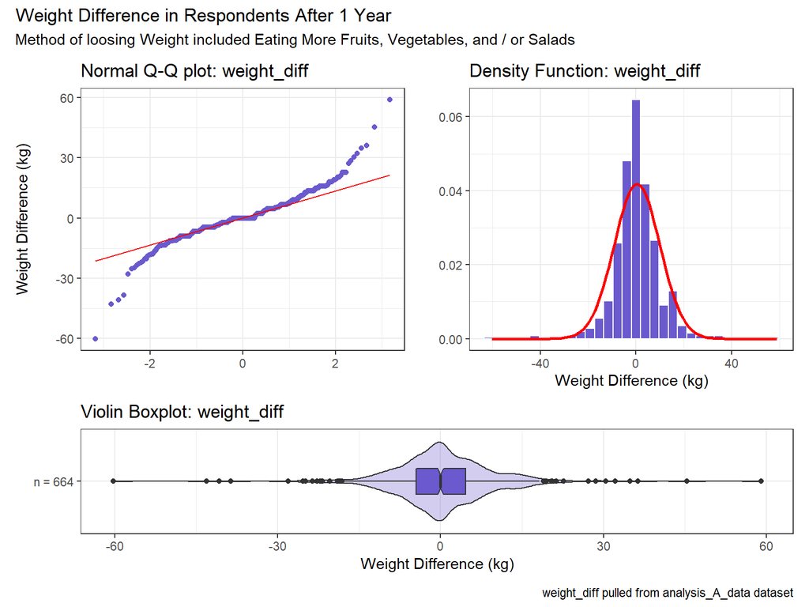

```r
p1 <- ggplot(analysis_A_data, aes(x = weight_diff)) +
    geom_histogram(aes(y = stat(density)), fill = "slateblue", col = "white", bins = nclass.scott(analysis_A_data$weight_diff)) +
    stat_function(fun = dnorm, args = list(mean = mean(analysis_A_data$weight_diff), sd = sd(analysis_A_data$weight_diff)), col = "red", lwd = 1) +
    labs(title = "Density Function: weight_diff", x = "Weight Difference (kg)", y = "") +
    theme_bw()

p2 <- ggplot(analysis_A_data, aes(sample = weight_diff)) +
    geom_qq(col = "slateblue") + geom_qq_line(col = "red") +
    labs(title = "Normal Q-Q plot: weight_diff", x = "", y = "Weight Difference (kg)") +
    theme_bw()

p3 <- ggplot(analysis_A_data, aes(x = "n = 664", y = weight_diff)) +
    geom_violin(fill = "slateblue", alpha = 0.3) +
    geom_boxplot(fill = "slateblue", width = 0.3, notch = TRUE) +
    labs(y = "Weight Difference (kg)", x = "", title = "Violin Boxplot: weight_diff") +
    theme_bw() +
    coord_flip()

(p2 + p1) / p3 +
  plot_layout(ncol = 1, height = c(5, 2)) +
  plot_annotation(title = "Weight Difference in Respondents After 1 Year", subtitle = "Method of loosing Weight included Eating More Fruits, Vegetables, and / or Salads", caption = "weight_diff pulled from analysis_A_data dataset")
```

The 664 observations above seem to suggest that a Wilcoxon signed rank approach would be the optimal choice here instead of a Normal model for the paired differences, as there definitely appears to be a substantial number of outliers in the paired differences, and the outliers appear to be uniformly distributed as opposed to being skewed in either direction in particular, as shown by both the graphs above and the near 0 level of skew<sub>1</sub> as calculated below:

```r
analysis_A_data %>%
  summarise(skew1 = (mean(weight_diff) - median(weight_diff))/sd(weight_diff)) %>%
  kable(digits = 3)
```

| skew1 |
| --- |
| 0.042 |

That said, a bootstrap approach here would also be appropriate, and the Project B instructions strongly recommended against using a Wilcoxon signed rank approach for this project - as such the bootstrap approach will be used to find the 90% confidence interval and point estimate for this analysis.

### 4.2.3 Did Pairing Help Reduce Nuisance Variation?

We would expect a strong correlation between the `whd020` and `whd050` weights in this repeated measures analysis where each subject is assessing their weight from last year and comparing it to their current weight for subjects that are actively trying to loose weight. To examine whether this pairing helped reduce nuisance variation though, the following scatterplot of the `whd020` and `whd050` scores was generated, supplemented by a Pearson correlation coefficient. The larger the correlation, the more that pairing will help reduce the impact of differences between subjects on the `whd020` score on the comparison we’re trying to make.

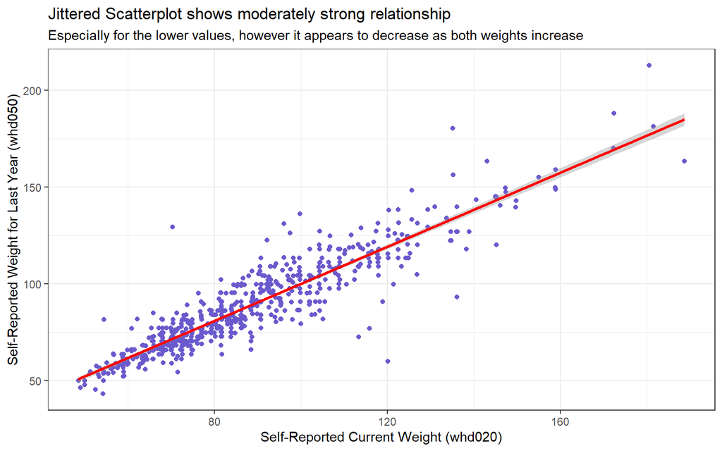

```r
ggplot(analysis_A_data, aes(x = whd020, y = whd050)) +
    geom_jitter(col = "slateblue") +
    geom_smooth(formula = y ~ x, method = "lm", col = "red") +
    theme_bw() +
    labs(title = "Jittered Scatterplot shows moderately strong relationship",
         subtitle = "Especially for the lower values, however it appears to decrease as both weights increase", x = "Self-Reported Current Weight (whd020)", y = "Self-Reported Weight for Last Year (whd050)")
```

We see a pretty strong linear relationship between `whd020` and `whd050` at lower weights, however as both weights increase the strength of the correlation appears to decrease. The Pearson correlation coefficient is shown below:

```r
analysis_A_data %>% select(whd020, whd050) %>% cor(.) %>%
    round(digits = 3) %>% kable()
```

|  | whd020 | whd050 |
| --- | --- | --- |
| whd020 | 1.00 | 0.92 |
| whd050 | 0.92 | 1.00 |

## 4.3 Main Analysis

As concluded from the initial results above, we’ll build a 90% confidence interval for the population mean of the `whd050 - whd020` differences using the bootstrap approach as shown below:

### 4.3.1 The Bootstrap approach for the mean from paired samples

Here is a 90% confidence interval for the population mean of the paired `whd050 - whd020` differences, as estimated by a bootstrap approach using a random seed of `431`. (*Note*: when you set a seed for this or other analyses in the project, pick something other than `431`.)

```r
set.seed(431)
smean.cl.boot(analysis_A_data$weight_diff, conf.int = 0.90)
```

```
      Mean      Lower      Upper
 0.3984940 -0.2169277  1.0079443
```

## 4.4 Conclusions

A natural next step would be to look at values of something like this over multiple years, or perhaps comparing respondents weights at more than just two stages. It would also be better to compare data across NHANES survey years to obtain examination weights as opposed to asking respondents to provide self-reported weights for both the present and 1 year ago.

# 5 Analysis B: Compare 2 Population Means using Independent Samples

## 5.1 The Question

Did respondents who participate in 10 minutes of continuous vigorous exercise a week have meaningfully different average body weight in kilograms than respondents who don’t participate in 10 minutes of continuous vigorous exercise a week?

## 5.2 Describing the Data

The range of the `bmxwt` data within each `paq650` group is shown below:

```r
mosaic::favstats(bmxwt ~ paq650, data = analysis_data) %>%
  kable(digits = 2)
```

| paq650 | min | Q1 | median | Q3 | max | mean | sd | n | missing |
| --- | --- | --- | --- | --- | --- | --- | --- | --- | --- |
| Yes | 39.3 | 67.05 | 78.0 | 91.30 | 180.8 | 81.38 | 20.39 | 810 | 0 |
| No | 36.2 | 66.47 | 79.2 | 96.12 | 242.6 | 83.31 | 24.22 | 1816 | 0 |

Next, we’ll use graphical and numerical summaries to assess whether the samples (of Yes and No respondents, separately) can *each* be modeled appropriately by a Normal distribution.

### 5.2.1 Graphical Summaries

The first graphical summary for this analysis is the violin boxplot, produced by the code below:

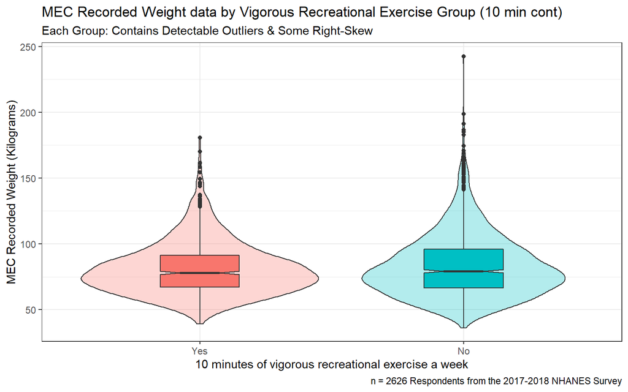

```r
ggplot(analysis_data, aes(x = paq650, y = bmxwt, fill = paq650)) +
  geom_violin(alpha = 0.3) +
  geom_boxplot(width = 0.3, notch = TRUE) +
  guides(fill = "none") +
  labs(title = "MEC Recorded Weight data by Vigorous Recreational Exercise Group (10 min cont)",
       subtitle = "Each Group: Contains Detectable Outliers & Some Right-Skew", caption = "n = 2626 Respondents from the 2017-2018 NHANES Survey",
       x = "10 minutes of vigorous recreational exercise a week", y = "MEC Recorded Weight (Kilograms)") +
  theme_bw()
```

There appear to be several candidate outliers in each group on the high end, suggesting possible potential for meaningful skew.

The Normal Q-Q plots below also demonstrate significant right skew in this data:

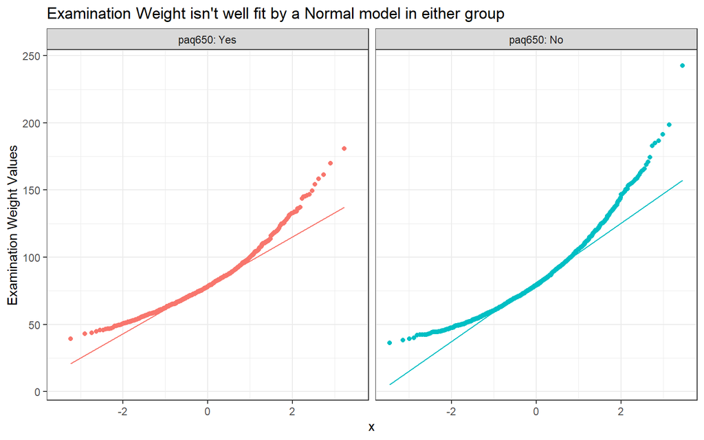

```r
ggplot(analysis_data, aes(sample = bmxwt, col = paq650)) +
  geom_qq() + geom_qq_line() +
  facet_wrap(~ paq650, labeller = "label_both") +
  guides(col = "none") +
  theme_bw() +
  labs(y = "Examination Weight Values",
       title = "Examination Weight isn't well fit by a Normal model in either group")
```

The right skew as indicated in both of these plots suggests that a test that requires Normal distributions in the populations wouldn’t be a good choice for this analysis.

### 5.2.2 Numerical Summaries

As shown from the summary below, there are 810 “Yes” and 1816 “No” respondents to the vigorous recreational exercise question for respondents that have recorded examination weight `bmxwt` values.

```r
mosaic::favstats(bmxwt ~ paq650, data = analysis_data) %>%
  kable()
```

| paq650 | min | Q1 | median | Q3 | max | mean | sd | n | missing |
| --- | --- | --- | --- | --- | --- | --- | --- | --- | --- |
| Yes | 39.3 | 67.050 | 78.0 | 91.300 | 180.8 | 81.37691 | 20.38873 | 810 | 0 |
| No | 36.2 | 66.475 | 79.2 | 96.125 | 242.6 | 83.31151 | 24.21586 | 1816 | 0 |

The skew<sub>1</sub> values for these summary statistics are shown below:

```r
analysis_data %>% group_by(paq650) %>%
  summarise(skew1 = round((mean(bmxwt) - median(bmxwt))/sd(bmxwt), 3))
```

| paq650 | skew1 |
| --- | --- |
| Yes | 0.166 |
| No | 0.170 |

For this data set, while the skew<sub>1</sub> for neither the “Yes” group nor the “No” group for vigorous recreational exercise break the 0.2 cutoff for “fairly substantial” right skew, it still looks like the right skew is large enough in both categories for vigorous recreational exercise to warrant avoiding tests that require Normality. As such it would appear that a Wilcoxon-Mann-Whitney rank sum test approach or a bootstrap approach would be ideal for determining a confidence interval and point estimate for this data. Again, as with the first analysis for this study, the Wilcoxon rank sum approach is not recommended for this project, so a bootstrap approach will be executed in the *Main Analysis* section below.

## 5.3 Main Analysis

As stated at the end of *Describing the Data* section above, the samples for this data set aren’t well described by Normal models or even symmetric ones, due to the amount of right skew and outliers. As such, a bootstrap approach will be used below to build a 90% confidence interval for the population mean, comparing `bmxwt` for people who answered “Yes” and “No” to the exercise question regarding whether they complete 10 continuous minutes of vigorous recreational exercise in a typical week.

### 5.3.1 The Bootstrap for comparing means from two independent samples

As mentioned above, the bootstrap approach was selected over the other approachs available because the data for this analysis are comprised of independent samples that aren’t normally distributed, and as such the bootstrap approach is the most appropriate method for estimating the difference in population means. The approach used below utilizes the `bootdif` function to accomplish this, which was loaded in from the `Love-boost.R` file, calculating a 90% confidence interval for the difference between the `paq650` “Yes” and `paq650` “No” population `bmxwt` distributions based on the bootstrap using a seed of `4312021`:

```r
set.seed(4312021)
analysis_data %$%
  bootdif(bmxwt, paq650, conf.level = 0.90)
```

```
Mean Difference            0.05            0.95
      1.9345952       0.3997217       3.4797207
```

Lastly, to reiterate, the bootstrap procedure would be most appropriate here for estimating the differences in the population means because of the lack of Normality in the samples.

## 5.4 Conclusions

At the 10% significance level, there is a statistically detectable difference between the population mean weight (kilograms) as measured and recorded for the 2017-2018 NHANES examination survey data for those who typically partake in vigorous recreational exercise for at least 10 continuous minutes a week and those who don’t typically partake in vigorous recreational exercise for at least 10 continuous minutes a week, based on our sample of respondents with complete data on `bmxwt`. This conclusion is motivated by a bootstrap estimate to compare the two `paq650` groups with complete data on survey examination weight `bmxwt`. I think that the notable right skew in data when grouped by `paq650`, along with the statistically detectable number of outliers seen in the violin boxplot suggests that the bootstrap approach is the best option for this analysis.

One potential step that could logically be taken next for this analysis would be to increase the respondent population by including participants from previous years of the NHANES survey, as only using the 2017-2018 NHANES data is a significant limitation of this study. Another potential step that could be taken could be to attempt to correct for the skew by transforming `bmxwt`.

# 6 Analysis C: Comparing 3+ Population Means via ANOVA

## 6.1 The Question

This analysis will compare `bmxwt` by `slq120`, using the analysis of variance, along with other related tools as well. The purpose of this analysis is to compare the mean `bmxwt` MEC recorded weight (kilograms) of the population represented by the respondents based on how often they felt overly sleepy during the day - Never, Rarely (1 time a month), Sometimes (2-4 times a month), Often (5-15 times a month), and Almost always (16-30 times a month). As with the previous analysis, there is no link between the respondents across the five `slq120` groups, so these samples are also independent. Additionally, as the *Describing the Data* section below will demonstrate, there are different numbers of subjects in all five `slq120` groups, so as a result it is impossible to match their `bmxwt` values. With all of this in mind, our research question for this analysis is as follows:

Is there a statistically detectable difference between the confidence intervals for `bmxwt` by `slq120` category, and are any of the `bmxwt` confidence intervals for each `slq120` category dectably different from each other?

## 6.2 Describing the Data

To begin with, let’s look at the range of the `bmxwt` data within each `slq120` group, as shown below:

```r
mosaic::favstats(bmxwt ~ slq120, data = analysis_data)
```

| slq120 | min | Q1 | median | Q3 | max | mean | sd | n | missing |
| --- | --- | --- | --- | --- | --- | --- | --- | --- | --- |
| Never | 36.2 | 63.575 | 73.50 | 86.900 | 242.6 | 77.74804 | 21.84707 | 460 | 0 |
| Rarely | 42.2 | 68.100 | 79.60 | 93.525 | 198.7 | 82.63750 | 21.52259 | 656 | 0 |
| Sometimes | 39.4 | 66.475 | 78.70 | 94.800 | 186.5 | 82.65078 | 22.98590 | 900 | 0 |
| Often | 38.2 | 69.375 | 82.25 | 100.250 | 191.3 | 86.69632 | 25.26544 | 408 | 0 |
| Almost always | 39.3 | 68.300 | 80.90 | 101.725 | 174.4 | 86.51931 | 24.90770 | 202 | 0 |

The category with the smallest number of respondents, the *Almost always* group, has 202 total respondents, while the next two categories with the smallest number of respondents are *Often* with 408, and *Never* with 460. While the number of respondents in each of these three categories is less than the minimum number of required subjects for this study as a whole (i.e. 500 respondents), each of these categories, as well as the other remaining two, *Rarely* and *Sometimes*, contains enough respondents in them that we should nevertheless be able to conclude something about the distributions of `bmxwt` in these `slq120` populations.

### 6.2.1 Graphical Summaries

One effective way of exploring the distributions of multiple independent samples is to examine a comparison boxplot - as such, one has been produced below with the following code:

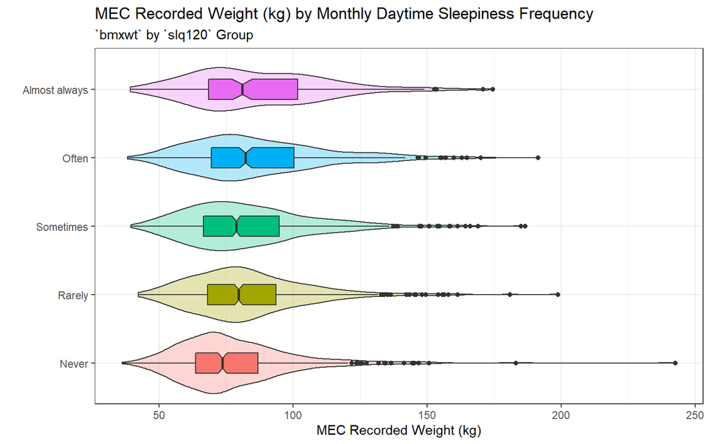

```r
ggplot(analysis_data, aes(x = slq120, y = bmxwt, fill = slq120)) +
  geom_violin(alpha = 0.3) +
  geom_boxplot(width = 0.3, notch = TRUE) +
  coord_flip() +
  guides(fill = "none") +
  theme_bw() +
  labs(title = "MEC Recorded Weight (kg) by Monthly Daytime Sleepiness Frequency",
       subtitle = "`bmxwt` by `slq120` Group",
       y = "MEC Recorded Weight (kg)",
       x = "")
```

- Notice that each level of daytime sleepiness frequency `slq120` demonstrates a potential issue with skew (i.e. right-skew) in the distribution of the `bmxwt` weights, a potential issue with outliers, or possibly some combination of both.

Histograms represent another simple and effective way to examine the distribution of `bmxwt` across each category of `slq120`. The code below creates a comparison histogram to this end:

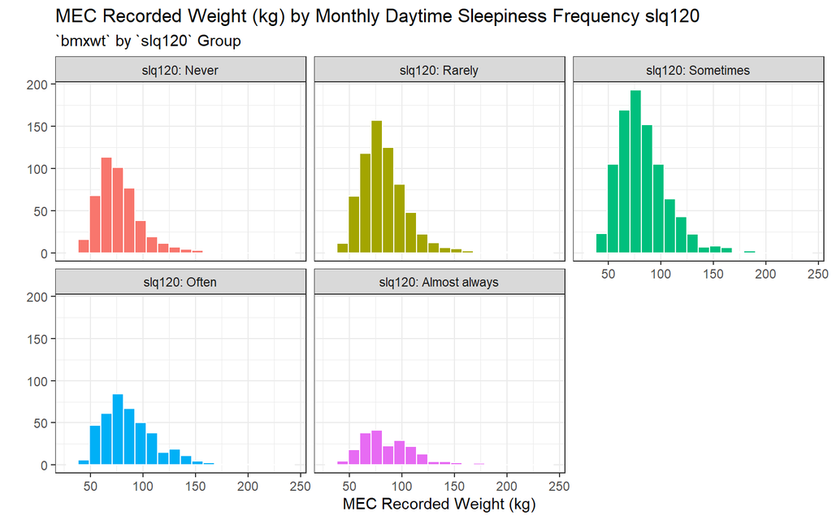

```r
ggplot(analysis_data, aes(x = bmxwt)) +
  geom_histogram(aes(fill = slq120), bins = 20, col = "white") +
  theme_bw() +
  facet_wrap(~ slq120, labeller = "label_both") +
  guides(fill = "none") +
  labs(title = "MEC Recorded Weight (kg) by Monthly Daytime Sleepiness Frequency slq120",
       subtitle = "`bmxwt` by `slq120` Group",
       y = "",
       x = "MEC Recorded Weight (kg)")
```

### 6.2.2 Numerical Summaries

Although this numeric summary for the `slq120` categories were already generated earlier in the *Describe the Data* section for this analysis, they have been provided again below:

```r
mosaic::favstats(bmxwt ~ slq120, data = analysis_data) %>%
  kable()
```

| slq120 | min | Q1 | median | Q3 | max | mean | sd | n | missing |
| --- | --- | --- | --- | --- | --- | --- | --- | --- | --- |
| Never | 36.2 | 63.575 | 73.50 | 86.900 | 242.6 | 77.74804 | 21.84707 | 460 | 0 |
| Rarely | 42.2 | 68.100 | 79.60 | 93.525 | 198.7 | 82.63750 | 21.52259 | 656 | 0 |
| Sometimes | 39.4 | 66.475 | 78.70 | 94.800 | 186.5 | 82.65078 | 22.98590 | 900 | 0 |
| Often | 38.2 | 69.375 | 82.25 | 100.250 | 191.3 | 86.69632 | 25.26544 | 408 | 0 |
| Almost always | 39.3 | 68.300 | 80.90 | 101.725 | 174.4 | 86.51931 | 24.90770 | 202 | 0 |

## 6.3 Main Analysis

As you’ll recall, we have at least two available methods for building statistical inferences when comparing more than two independent samples.

- Analysis of Variance
- The Kruskal-Wallis Test

There is also a bootstrap approach but we’ll defer discussion of that until 432.

### 6.3.1 Kruskal-Wallis Test

```r
analysis_data %$%
  kruskal.test(bmxwt ~ slq120)
```

```
    Kruskal-Wallis rank sum test

data:  bmxwt by slq120
Kruskal-Wallis chi-squared = 41.065, df = 4, p-value = 2.606e-08
```

### 6.3.2 Analysis of Variance

```r
analysis_data %$%
  lm(bmxwt ~ slq120) %>%
  anova()
```

|  | Df | Sum Sq | Mean Sq | F value | Pr(>F) |
| --- | --- | --- | --- | --- | --- |
| slq120 | 4 | 20746.83 | 5186.7081 | 9.836864 | 6.738615e-08 |
| Residuals | 2621 | 1381981.25 | 527.2725 | NA | NA |

### 6.3.3 Holm approach to Pairwise Comparisons of Means

We have two approaches available for dealing with multiple comparisons. If we had not pre-planned the full set of pairwise comparisons of `bmxwt` across the `slq120` categories, or if we wanted to use a fairly conservative approach, we could apply a Holm correction to our comparisons. This works reasonably well even with an unbalanced design, such as we have here.

```r
analysis_data %$%
  pairwise.t.test(bmxwt, slq120, p.adjust = "holm")
```

```
    Pairwise comparisons using t tests with pooled SD

data:  bmxwt and slq120

              Never   Rarely Sometimes Often
Rarely        0.0033  -      -         -
Sometimes     0.0016  1.0000 -         -
Often         1.1e-07 0.0255 0.0191    -
Almost always 5.7e-05 0.1223 0.1223    1.0000

P value adjustment method: holm
```

### 6.3.4 Tukey’s Honestly Significant Differences approach to Pairwise Comparisons of Means

The Tukey HSD approach requires us to use the `aov` approach to specifying the ANOVA model, as opposed to the `anova with lm` approach we took above. The results for `aov` are identical, as you can see below.

```r
analysis_data %$% aov(bmxwt ~ slq120) %>% summary()
```

```
              Df  Sum Sq Mean Sq F value   Pr(>F)
slq120         4   20747    5187   9.837 6.74e-08 ***
Residuals   2621 1381981     527
---
Signif. codes:  0 '***' 0.001 '**' 0.01 '*' 0.05 '.' 0.1 ' ' 1
```

Now, we run the Tukey HSD comparisons, both in a plot and table of results. As specified previously, we’ll use a 90% confidence level across the set of comparisons.

```r
TukeyHSD(aov(analysis_data$bmxwt ~ analysis_data$slq120), conf.level = 0.90)
```

```
  Tukey multiple comparisons of means
    90% family-wise confidence level

Fit: aov(formula = analysis_data$bmxwt ~ analysis_data$slq120)

$`analysis_data$slq120`
                               diff        lwr       upr     p adj
Rarely-Never             4.88945652  1.4530537  8.325859 0.0042897
Sometimes-Never          4.90273430  1.6640241  8.141445 0.0018619
Often-Never              8.94828005  5.1054279 12.791132 0.0000001
Almost always-Never      8.77126345  4.0017157 13.540811 0.0000617
Sometimes-Rarely         0.01327778 -2.8876334  2.914189 1.0000000
Often-Rarely             4.05882353  0.4960221  7.621625 0.0407169
Almost always-Rarely     3.88180693 -0.6651291  8.428743 0.2198945
Often-Sometimes          4.04554575  0.6730195  7.418072 0.0264172
Almost always-Sometimes  3.86852915 -0.5309034  8.267962 0.1938556
Almost always-Often     -0.17701660 -5.0384233  4.684390 0.9999854
```

Note that in the plot below, we see these results a bit more clearly after we adjust the margins of the plot and use the `las = 1` bit at the end of the plotting call to get the x and y axis labels to be horizontal.

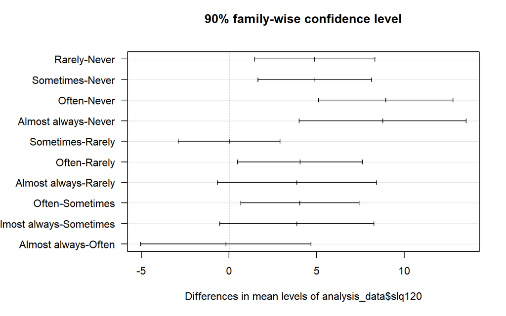

```r
mar.default <- c(5,6,4,2) + 0.1
par(mar = mar.default + c(0, 4, 0, 0))
plot(TukeyHSD(aov(analysis_data$bmxwt ~ analysis_data$slq120),
              conf.level = 0.90), las = 1)
```

```r
par(mar = mar.default)
```

## 6.4 Conclusions

# 7 Analysis D: Two-Way (2 x 2) Contingency Table

## 7.2 Describing the Data

Let’s look at the 2x2 table we get.

```r
table(analysis_data$whq065, analysis_data$rxduse)
```

```
       Yes   No
  Yes  305  934
  No   251 1136
```

Those names could use some work, I think.

```r
analysis_D_data <- analysis_data %>%
  mutate(weight_change = fct_recode(factor(whq065),
                                "Intentional" = "Yes",
                                "Un-intentional" = "No"),
         weight_change = fct_relevel(weight_change, "Intentional"),
         prescription_use = fct_recode(factor(rxduse),
                                 "Used Prescriptions" = "Yes",
                                 "No Prescriptions" = "No"),
         prescription_use = fct_relevel(prescription_use, "Used Prescriptions"))
```

```r
analysis_D_data %>% tabyl(weight_change, prescription_use)
```

| weight_change | Used Prescriptions | No Prescriptions |
| --- | --- | --- |
| Intentional | 305 | 934 |
| Un-intentional | 251 | 1136 |

## 7.3 Main Analysis

I **strongly encourage** you to use the Bayesian augmentation where we add two successes and add two failures, as recommended in Agresti and Coull, and to use 90% confidence levels. To accomplish this I’ll use the `twoby2` function in the `Epi` package.

```r
t1 <- analysis_D_data %$% table(weight_change, prescription_use)

twoby2(t1 + 2, conf.level = 0.90) # uses Bayesian augmentation, 90% confidence level
```

```
2 by 2 table analysis:
------------------------------------------------------
Outcome   : Used Prescriptions
Comparing : Intentional vs. Un-intentional

               Used Prescriptions No Prescriptions    P(Used Prescriptions)
Intentional                   307              936                   0.2470
Un-intentional                253             1138                   0.1819
               90% conf. interval
Intentional       0.2274   0.2676
Un-intentional    0.1655   0.1995

                                   90% conf. interval
             Relative Risk: 1.3579    1.1995   1.5372
         Sample Odds Ratio: 1.4753    1.2605   1.7268
Conditional MLE Odds Ratio: 1.4751    1.2548   1.7346
    Probability difference: 0.0651    0.0388   0.0915

             Exact P-value: 0.0000
        Asymptotic P-value: 0.0000
------------------------------------------------------
```

### 7.3.1 Checking Assumptions

Since each cell in our (non-augmented) 2x2 table is at least 5, R throws no warning messages. We should be reasonably comfortable with the chi-square test of independence here. If every cell was 10 or more, we’d be even more comfortable.

### 7.3.2 What If We Wanted to Type in the Table Ourselves?

With the `twobytwo` function available in the `Love-boost.R` script, we can directly obtain 90% confidence intervals. For example, suppose we had the following data, pulled from our 2016 survey:

| 2016 Survey | Drank Tea Recently | Didn’t Drink Tea |
| --- | --- | --- |
| Not Born in US | 21 | 10 |
| US Born | 20 | 18 |

Suppose we wanted to use `twobytwo` and the +2/+4 Bayesian augmentation (adding 2 to the count in each cell of our 2x2 table) and a 90% confidence interval for this comparison, to see whether the population proportions who drank tea recently differ between those born in and out of the US.

```r
twobytwo(21+2, 10+2, 20+2, 18+2,
         "Not US Born", "US Born", "Drank Tea", "No Tea",
         conf.level = 0.90)
```

```
2 by 2 table analysis:
------------------------------------------------------
Outcome   : Drank Tea
Comparing : Not US Born vs. US Born

            Drank Tea No Tea    P(Drank Tea) 90% conf. interval
Not US Born        23     12          0.6571    0.5162   0.7749
US Born            22     20          0.5238    0.3982   0.6465

                                   90% conf. interval
             Relative Risk: 1.2545    0.9160   1.7181
         Sample Odds Ratio: 1.7424    0.8024   3.7839
Conditional MLE Odds Ratio: 1.7299    0.7276   4.1948
    Probability difference: 0.1333   -0.0512   0.3036

             Exact P-value: 0.2561
        Asymptotic P-value: 0.2389
------------------------------------------------------
```

## 7.4 Conclusions

Then we’d write more about limitations and opportunities for further work, were this an actual Study 1, instead of just a demonstration.

# 8 Session Information

[session information not shown]